## **Diabetes Readmission Classification**

## **Data Set Description**

The dataset represents 10 years (1999-2008) of clinical care at 130 US hospitals and integrated delivery networks. It includes over 50 features representing patient and hospital outcomes. Information was extracted from the database for encounters that satisfied the following criteria. (1) It is an inpatient encounter (a hospital admission). (2) It is a diabetic encounter, that is, one during which any kind of diabetes was entered to the system as a diagnosis. (3) The length of stay was at least 1 day and at most 14 days. (4) Laboratory tests were performed during the encounter. (5) Medications were administered during the encounter. The data contains such attributes as patient number, race, gender, age, admission type, time in hospital, medical specialty of admitting physician, number of lab test performed, HbA1c test result, diagnosis, number of medication, diabetic medications, number of outpatient, inpatient, and emergency visits in the year before the hospitalization, etc.

For more information about the dataset please visit https://archive.ics.uci.edu/dataset/296/diabetes+130-us+hospitals+for+years+1999-2008

```
## tibble [101,766 × 50] (S3: tbl_df/tbl/data.frame)
##  $ encounter_id            : int [1:101766] 2278392 149190 64410 500364 16680 35754 55842 63768 12522 15738 ...
##  $ patient_nbr             : int [1:101766] 8222157 55629189 86047875 82442376 42519267 82637451 84259809 114882984 48330783 63555939 ...
##  $ race                    : chr [1:101766] "Caucasian" "Caucasian" "AfricanAmerican" "Caucasian" ...
##  $ gender                  : chr [1:101766] "Female" "Female" "Female" "Male" ...
##  $ age                     : chr [1:101766] "[0-10)" "[10-20)" "[20-30)" "[30-40)" ...
##  $ weight                  : chr [1:101766] "?" "?" "?" "?" ...
##  $ admission_type_id       : int [1:101766] 6 1 1 1 1 2 3 1 2 3 ...
##  $ discharge_disposition_id: int [1:101766] 25 1 1 1 1 1 1 1 1 3 ...
##  $ admission_source_id     : int [1:101766] 1 7 7 7 7 2 2 7 4 4 ...
##  $ time_in_hospital        : int [1:101766] 1 3 2 2 1 3 4 5 13 12 ...
##  $ payer_code              : chr [1:101766] "?" "?" "?" "?" ...
##  $ medical_specialty       : chr [1:101766] "Pediatrics-Endocrinology" "?" "?" "?" ...
##  $ num_lab_procedures      : int [1:101766] 41 59 11 44 51 31 70 73 68 33 ...
##  $ num_procedures          : int [1:101766] 0 0 5 1 0 6 1 0 2 3 ...
```

[output cut: 36 more lines]

According to the information that accompanies the data set, we are aware of the existence of missing values for certain variables, which have been coded as “?”; therefore, in order to give them the appropriate treatment, we will recode them as NA.

```r
                diabetes_na <-  as_tibble(sapply(data_diabetes,                           # Replace values in all columns
                                  function(x) replace(x, x %in% "?", NA)))

                                  sapply(diabetes_na, function(x) sum(is.na(x)))
```

```
##             encounter_id              patient_nbr                     race
##                        0                        0                     2273
##                   gender                      age                   weight
##                        0                        0                    98569
##        admission_type_id discharge_disposition_id      admission_source_id
##                        0                        0                        0
##         time_in_hospital               payer_code        medical_specialty
##                        0                    40256                    49949
##       num_lab_procedures           num_procedures          num_medications
##                        0                        0                        0
##        number_outpatient         number_emergency         number_inpatient
##                        0                        0                        0
##                   diag_1                   diag_2                   diag_3
##                       21                      358                     1423
##         number_diagnoses            max_glu_serum                A1Cresult
##                        0                        0                        0
##                metformin              repaglinide              nateglinide
##                        0                        0                        0
##           chlorpropamide              glimepiride            acetohexamide
##                        0                        0                        0
##                glipizide                glyburide              tolbutamide
##                        0                        0                        0
##             pioglitazone            rosiglitazone                 acarbose
##                        0                        0                        0
##                 miglitol             troglitazone               tolazamide
##                        0                        0                        0
##                  examide              citoglipton                  insulin
##                        0                        0                        0
##      glyburide.metformin      glipizide.metformin glimepiride.pioglitazone
##                        0                        0                        0
##  metformin.rosiglitazone   metformin.pioglitazone                   change
##                        0                        0                        0
##              diabetesMed               readmitted
##                        0                        0
```

```r
                    diabetes_na_percent <- colSums(is.na(diabetes_na))/nrow(diabetes_na)

                    miss_percent <- as.data.frame(formattable::percent(round(diabetes_na_percent, 4)))

                    names(miss_percent) <- "Percentage"

                df_miss <-  miss_percent %>%
                            arrange(desc(Percentage)) %>%
                            filter(Percentage > 0)

                df_miss   %>%
                kbl() %>%
                kable_paper("hover", full_width = F)
```

|  | Percentage |
| --- | --- |
| weight | 96.86% |
| medical_specialty | 49.08% |
| payer_code | 39.56% |
| race | 2.23% |
| diag_3 | 1.40% |
| diag_2 | 0.35% |
| diag_1 | 0.02% |

##**Dataset Imputation K-nearest Neighbors**

We can observe that the variables wight, medical_specialty, payer_code have too significant percentages to be imputed. The variables race, diag_3, diag_diag_2 and diag_1 have an insignificant percentage of missing values so we proceed with their imputation in case they are relevant for our model using a nearest neighbor imputation.

```r
                                  ## Exclude vars with a significant missing values percentage
                                  diabetes_imput <-   diabetes_na %>%
                                                      dplyr::select(-weight, -medical_specialty, -payer_code)

                                  ## Imputing missing values
                                  diabetes_imput <- kNN(diabetes_imput, k = 5)

                                  diabetes_imput <- diabetes_imput %>%
                                                    dplyr::select(!(ends_with('imp')))

                                  sapply(diabetes_imput, function(x) sum(is.na(x)))
```

```
##             encounter_id              patient_nbr                     race
##                        0                        0                        0
##                   gender                      age        admission_type_id
##                        0                        0                        0
## discharge_disposition_id      admission_source_id         time_in_hospital
##                        0                        0                        0
##       num_lab_procedures           num_procedures          num_medications
##                        0                        0                        0
##        number_outpatient         number_emergency         number_inpatient
##                        0                        0                        0
##                   diag_1                   diag_2                   diag_3
##                        0                        0                        0
##         number_diagnoses            max_glu_serum                A1Cresult
##                        0                        0                        0
##                metformin              repaglinide              nateglinide
##                        0                        0                        0
##           chlorpropamide              glimepiride            acetohexamide
##                        0                        0                        0
##                glipizide                glyburide              tolbutamide
##                        0                        0                        0
##             pioglitazone            rosiglitazone                 acarbose
##                        0                        0                        0
##                 miglitol             troglitazone               tolazamide
##                        0                        0                        0
##                  examide              citoglipton                  insulin
##                        0                        0                        0
##      glyburide.metformin      glipizide.metformin glimepiride.pioglitazone
##                        0                        0                        0
##  metformin.rosiglitazone   metformin.pioglitazone                   change
##                        0                        0                        0
##              diabetesMed               readmitted
##                        0                        0
```

```r
                                      diabetes_na_percent <- colSums(is.na(diabetes_imput))/nrow(diabetes_imput)

                                      miss_percent <- as.data.frame(formattable::percent(round(diabetes_na_percent, 4)))

                                      names(miss_percent) <- "Percentage"

                                      df_miss <-  miss_percent %>%
                                                  arrange(desc(Percentage))


                                                  df_miss  %>%
                                                  kbl() %>%
                                                  kable_paper("hover", full_width = F)
```

|  | Percentage |
| --- | --- |
| encounter_id | 0.00% |
| patient_nbr | 0.00% |
| race | 0.00% |
| gender | 0.00% |
| age | 0.00% |
| admission_type_id | 0.00% |
| discharge_disposition_id | 0.00% |
| admission_source_id | 0.00% |
| time_in_hospital | 0.00% |
| num_lab_procedures | 0.00% |
| num_procedures | 0.00% |
| num_medications | 0.00% |
| number_outpatient | 0.00% |
| number_emergency | 0.00% |
| number_inpatient | 0.00% |
| diag_1 | 0.00% |
| diag_2 | 0.00% |
| diag_3 | 0.00% |
| number_diagnoses | 0.00% |
| max_glu_serum | 0.00% |
| A1Cresult | 0.00% |
| metformin | 0.00% |
| repaglinide | 0.00% |
| nateglinide | 0.00% |
| chlorpropamide | 0.00% |
| glimepiride | 0.00% |
| acetohexamide | 0.00% |
| glipizide | 0.00% |
| glyburide | 0.00% |
| tolbutamide | 0.00% |
| pioglitazone | 0.00% |
| rosiglitazone | 0.00% |
| acarbose | 0.00% |
| miglitol | 0.00% |
| troglitazone | 0.00% |
| tolazamide | 0.00% |
| examide | 0.00% |
| citoglipton | 0.00% |
| insulin | 0.00% |
| glyburide.metformin | 0.00% |
| glipizide.metformin | 0.00% |
| glimepiride.pioglitazone | 0.00% |
| metformin.rosiglitazone | 0.00% |
| metformin.pioglitazone | 0.00% |
| change | 0.00% |
| diabetesMed | 0.00% |
| readmitted | 0.00% |

We observed that the variables with significant percentages of missing values were excluded and the other variables with non-significant percentages of missing values were imputed.

Additionally, we perform the integer format assignment for the numeric variables of our dataset

```r
                    diabetes_imput$time_in_hospital <- as.integer(diabetes_imput$time_in_hospital)
                    diabetes_imput$num_lab_procedures <- as.integer(diabetes_imput$num_lab_procedures)
                    diabetes_imput$num_procedures <- as.integer(diabetes_imput$num_procedures)
                    diabetes_imput$num_medications <- as.integer(diabetes_imput$num_medications)
                    diabetes_imput$number_outpatient <- as.integer(diabetes_imput$number_outpatient)
                    diabetes_imput$number_emergency <- as.integer(diabetes_imput$number_emergency)
                    diabetes_imput$number_inpatient <- as.integer(diabetes_imput$number_inpatient)
                    diabetes_imput$number_diagnoses <- as.integer(diabetes_imput$number_diagnoses)
```

##**Model Specification**

For the development of our exercise we define as variables of interest those variables:

- readmitted (depended variable)
- age
- gender
- race
- diabetesMed
- time in hospital
- num lab procedures
- num medications
- num outpatient
- number emergency
- number inpatient
- number diagnosis

According to the investigation of relevant issues with our case study and according to the literature consulted we have discarded the variabels corresponding to the application of different drugs to patients. This is due to the fact that the same information may be contained in variables such as the number of drugs applied, causing an overspecification of the model.

Another reason for focusing on the aforementioned variables is the limitation of resources in terms of computational capacity. All the variables discarded are binomial categorical variables. When performing a One Hot Encoding the dimensions of the dataset exceed the available computational capacity.

```r
                              VAR_INTEREST <-   diabetes_imput %>%
                                                dplyr::select(readmitted, age, gender, race, diabetesMed,
                                                              time_in_hospital, starts_with("num"))

                              VAR_INTEREST <- as.vector(unlist(names(VAR_INTEREST)))

                                                  VAR_INTEREST %>%
                                                  kbl() %>%
                                                  kable_paper("hover", full_width = F)
```

| x |
| --- |
| readmitted |
| age |
| gender |
| race |
| diabetesMed |
| time_in_hospital |
| num_lab_procedures |
| num_procedures |
| num_medications |
| number_outpatient |
| number_emergency |
| number_inpatient |
| number_diagnoses |

We then assign the factor format to the categorical variables selected for our model.

```r
                        DIABETES_SELECT <-  diabetes_imput %>%
                                            dplyr::select(VAR_INTEREST) %>%
                                            dplyr::mutate_if(is.character, as.factor)
```

We conducted an exploration of the age variable due to its considerable number of categories:

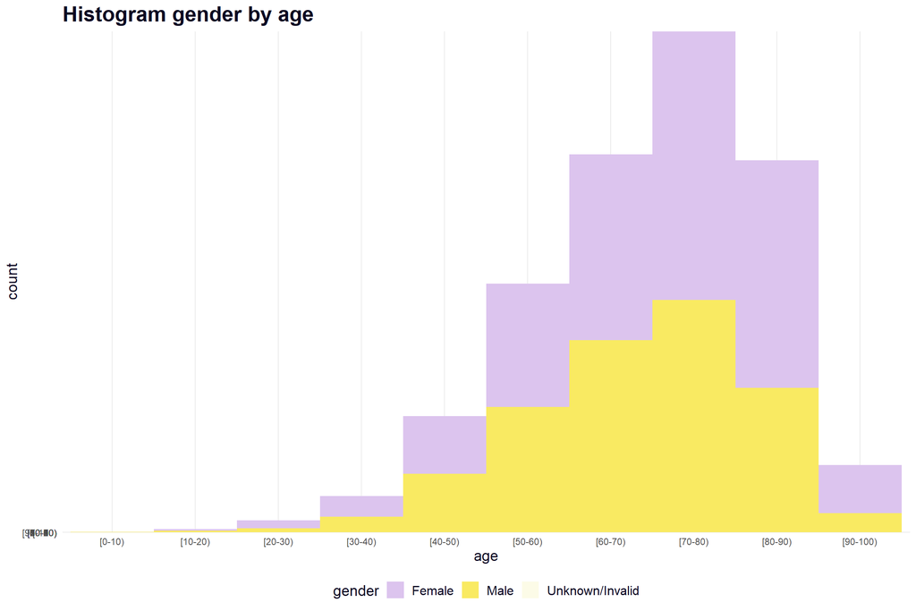

```r
         hist_gender_age_graph <- DIABETES_SELECT %>%
                                  dplyr::select(age, gender, readmitted) %>%
                                  ggplot(aes(x=age,
                                            y=age,
                                            fill = gender)) +
                                  geom_bar(stat="identity",width=1) +
                                  ggtitle("Histogram gender by age") +
                                  theme_minimal() +
                                  scale_fill_manual(values = c("#Dcc4EE", "#F9EA62", "#FCFBE7")) +
                                  theme(
                                      plot.title = element_text(color="#0D0923",
                                                                size=20,
                                                                face="bold"),
                                      axis.title.x = element_text(color="#0D0923",
                                                                  size=14
                                                                  ),
                                      axis.title.y = element_text(color="#0D0923",
                                                                  size=14
                                                                  ),
                                      legend.position = "bottom",
                                      legend.title = element_text(colour="#0D0923",
                                                                  size=14
                                                                  ),
                                      legend.text = element_text(colour="#0D0923",
                                                                size=12
                                                                ),
                                      panel.spacing = unit(0.1, "lines"),
                                      strip.text.x = element_text(size = 12)
                                      ) +
                                  xlab("age") +
                                  ylab("count")

             hist_gender_age_graph
```

It can be observed that the age variable is mainly concentrated in ages around 70 and 80 years old. This variable will be recoded to facilitate the development of the present exercise in three categories: ages under 60 years, 61 to 79 years and over 80 years

```r
                DIABETES_SELECT   <-    DIABETES_SELECT %>%
                                        mutate(new_age = ifelse(age %in% c("[0-10)", "[10-20)", "[20-30)",
                                                                          "[30-40)", "[40-50)", "[50-60)"),
                                                                          "[0-60)",
                                                    ifelse(age %in% c("[60-70)", "[70-80)"),
                                                           "[60-80)",
                                                    ifelse(age %in% c("[80-90)", "[90-100)"),
                                                           "[90-100)", 999
                                                          ))),
                                         new_age = as.factor(new_age),
                                         class_readmitted = as.factor(readmitted),
                                         class_readmitted = recode(class_readmitted,
                                                                  '<30' = 0,
                                                                  '>30' = 1,
                                                                  'NO' = 2
                                                                   )
                                                          )
```

The new recategorization of the age variable is distributed as follows:

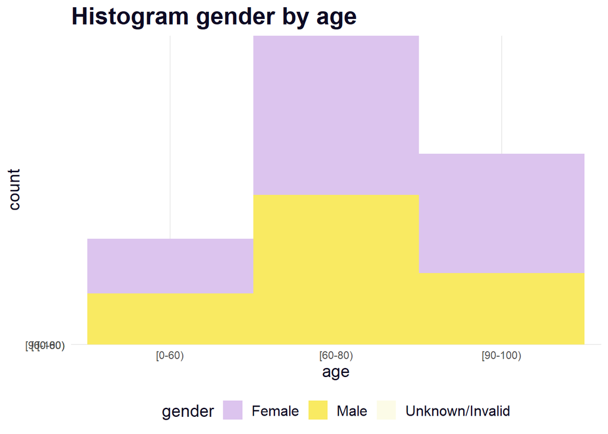

```r
                     hist_gender_age_graph <- DIABETES_SELECT %>%
                                                      dplyr::select(new_age, gender, readmitted) %>%
                                                      ggplot(aes(x=new_age,
                                                                y=new_age,
                                                                fill = gender)) +
                                                      geom_bar(stat="identity",width=1) +
                                                      ggtitle("Histogram gender by age") +
                                                      theme_minimal() +
                                                      scale_fill_manual(values = c("#Dcc4EE", "#F9EA62", "#FCFBE7")) +
                                                      theme(
                                                          plot.title = element_text(color="#0D0923",
                                                                                    size=20,
                                                                                    face="bold"),
                                                          axis.title.x = element_text(color="#0D0923",
                                                                                      size=14
                                                                                      ),
                                                          axis.title.y = element_text(color="#0D0923",
                                                                                      size=14
                                                                                      ),
                                                          legend.position = "bottom",
                                                          legend.title = element_text(colour="#0D0923",
                                                                                      size=14
                                                                                      ),
                                                          legend.text = element_text(colour="#0D0923",
                                                                                    size=12
                                                                                    ),
                                                          panel.spacing = unit(0.1, "lines"),
                                                          strip.text.x = element_text(size = 12)
                                                          ) +
                                                      xlab("age") +
                                                      ylab("count")

                                 hist_gender_age_graph
```

Definimos nuestro conjunto de datos de entrenamiento y testeo con una separación 80/20

```r
                 # Set seed for reproducibility
                 set.seed(423563)
                 # Set the upper bound for the number of rows to be in the training set
                 sample_size <- floor(0.8*nrow(DIABETES_SELECT))

                 dataset_learn <- DIABETES_SELECT %>%
                                  select(-readmitted, -age)


                 # Assign rows to training/test sets randomly in 80/20 proportion
                 train <- sample(seq_len(nrow(dataset_learn)), size = sample_size)

                 # Separate training and test sets
                 trainset <- dataset_learn[train, ]
                 testset <- dataset_learn[-train, ]
```

##**One Hot Encoding** Since our model has categorical variables, we must give them an adequate treatment so that they are processed correctly by our model, for which we carry out a One Hot Encoding

```r
                      DIABETES_CHARS <- DIABETES_SELECT %>%
                                        select_if(function(x) is.factor(x)) %>%
                                        dplyr::select(-readmitted, -age)

                      vars    <- as.vector(unlist(names(DIABETES_CHARS)))


                          # Crear el plan de tratamiento a partir de bikesJuly (los datos de entrenamiento)
                          treatplan <- designTreatmentsZ(trainset, vars, verbose = FALSE)

                          # Obtener las variables "clean" y "lev" del scoreFrame
                          newvars <- treatplan %>%
                                      use_series(scoreFrame) %>%
                                      filter(code %in% c("clean", "lev")) %>%  # obtener las variables de interes
                                      use_series(varName)                     # obtener columna varName


                          newvars %>%
                          kbl() %>%
                          kable_paper("hover", full_width = F)
```

| x |
| --- |
| gender_lev_x_Female |
| gender_lev_x_Male |
| gender_lev_x_Unknown_slash_Invalid |
| race_lev_x_AfricanAmerican |
| race_lev_x_Asian |
| race_lev_x_Caucasian |
| race_lev_x_Hispanic |
| race_lev_x_Other |
| diabetesMed_lev_x_No |
| diabetesMed_lev_x_Yes |
| new_age_lev_x_obrack_0_minus_60_cparen_ |
| new_age_lev_x_obrack_60_minus_80_cparen_ |
| new_age_lev_x_obrack_90_minus_100_cparen_ |

```r
                          # Prepare the training data
                          trainset.treat <- vtreat::prepare(treatplan, trainset,  varRestriction = newvars)

                          # PPreparar la data de entrenamiento
                          testset.treat <- vtreat::prepare(treatplan, testset, varRestriction = newvars)

                          # Verificar la estrcutura de la data tratada
                          #str(trainset.treat)
                          #str(trainset.treat)
```

After performing our One Hot Encoding we proceed to identify the number of trees where our model converges to the minimum of the logloss function.

Since the output of our model has more than two categories, we defined a softmax function suitable for mutliclass classification models.

```r
                    # seed
                    set.seed(423563)
                    # nummber of classes
                    num_class <- 3

                    # Ejecutar xgb.cv
                    cv <- xgb.cv(data = as.matrix(trainset.treat),
                                label = trainset$class_readmitted,
                                nrounds = 50,
                                nfold = 5,
                                objective = "multi:softmax",
                                num_class = num_class,
                                eta = 0.75,
                                max_depth = 5,
                                early_stopping_rounds = 5,
                                verbose = FALSE   # en silencio
                    )

                    # Get log evaluetion parameter
                      elog <- cv$evaluation_log

                    # Determinaer cuantos arboles minimizan el RMSE
                      elog %>%
                    # logloss minimum
                      summarize(ntrees.train = which.min(train_mlogloss_mean),
                                ntrees.test  = which.min(test_mlogloss_mean)) %>%
                      kbl() %>%
                      kable_paper("hover", full_width = F)
```

| ntrees.train | ntrees.test |
| --- | --- |
| 12 | 7 |

```r
                    set.seed(423563)

                    # Optimal number of trees
                    ntrees <- 12

                    levels(trainset$class_readmitted)
```

[output not shown]

```r
                    # xgboost execution
                    diabetes_model_xgb <-   xgboost(data = as.matrix(trainset.treat), # data de entrenamiento como matrix
                                               label =  trainset$class_readmitted,  # columna de resultados
                                               nrounds = ntrees,       # numero de arboles a cultivar
                                               objective = "multi:softmax", # objetivo
                                               num_class = num_class,
                                               eta = 0.75,
                                               max_depth = 5,
                                               verbose = FALSE  # silent
                                                )

                      # Predictions
                      testset$pred <- predict(diabetes_model_xgb, as.matrix(testset.treat))
```

```r
                                        testset %>%
                                        mutate(residuals = class_readmitted - pred) %>%
                                        summarize(rmse = sqrt(mean(residuals^2))) %>%
                                        kbl() %>%
                                        kable_paper("hover", full_width = F)
```

| rmse |
| --- |
| 0.8972187 |

We also observed a stable behavior of the logloss function of our model

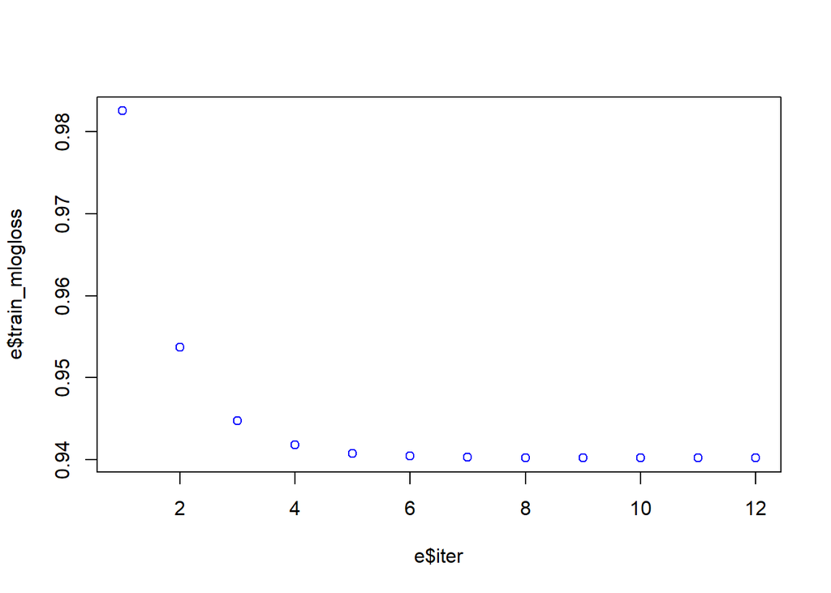

```r
e <- data.frame(diabetes_model_xgb$evaluation_log)
plot(e$iter, e$train_mlogloss, col = 'blue')
lines(e$iter, e$test_mlogloss, col = 'red')
```

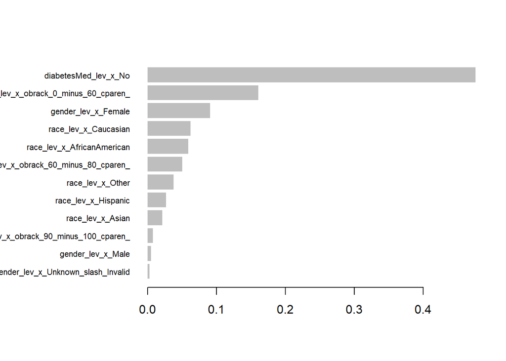

```r
                      imp_fearture <- xgb.importance(colnames(trainset.treat),
                                                      model = diabetes_model_xgb)

                        xgb.plot.importance(imp_fearture)
```